# Risk Factor Analysis

## Outcome Variable

**Outcome Variable:** haz

## Predictor Variables

**Intervention Variable:** predfeed3

**Adjustment Set:**

unadjusted

## Stratifying Variables

The analysis was stratified on these variable(s):

- agecat
- studyid
- country

## Data Summary

| agecat | studyid | country | predfeed3 | n_cell | n |
| --- | --- | --- | --- | --- | --- |
| Birth | EE | PAKISTAN | 1 | 35 | 35 |
| Birth | EE | PAKISTAN | 0 | 0 | 35 |
| Birth | GMS-Nepal | NEPAL | 1 | 380 | 458 |
| Birth | GMS-Nepal | NEPAL | 0 | 78 | 458 |
| Birth | JiVitA-3 | BANGLADESH | 1 | 12017 | 13276 |
| Birth | JiVitA-3 | BANGLADESH | 0 | 1259 | 13276 |
| Birth | JiVitA-4 | BANGLADESH | 1 | 105 | 116 |
| Birth | JiVitA-4 | BANGLADESH | 0 | 11 | 116 |
| Birth | MAL-ED | BANGLADESH | 1 | 176 | 215 |
| Birth | MAL-ED | BANGLADESH | 0 | 39 | 215 |
| Birth | MAL-ED | BRAZIL | 1 | 24 | 57 |
| Birth | MAL-ED | BRAZIL | 0 | 33 | 57 |
| Birth | MAL-ED | INDIA | 1 | 29 | 41 |
| Birth | MAL-ED | INDIA | 0 | 12 | 41 |
| Birth | MAL-ED | NEPAL | 1 | 14 | 26 |
| Birth | MAL-ED | NEPAL | 0 | 12 | 26 |
| Birth | MAL-ED | PERU | 1 | 150 | 223 |
| Birth | MAL-ED | PERU | 0 | 73 | 223 |
| Birth | MAL-ED | SOUTH AFRICA | 1 | 33 | 100 |
| Birth | MAL-ED | SOUTH AFRICA | 0 | 67 | 100 |
| Birth | MAL-ED | TANZANIA, UNITED REPUBLIC OF | 1 | 26 | 102 |
| Birth | MAL-ED | TANZANIA, UNITED REPUBLIC OF | 0 | 76 | 102 |
| 6 months | EE | PAKISTAN | 1 | 39 | 39 |
| 6 months | EE | PAKISTAN | 0 | 0 | 39 |
| 6 months | GMS-Nepal | NEPAL | 1 | 367 | 441 |
| 6 months | GMS-Nepal | NEPAL | 0 | 74 | 441 |
| 6 months | JiVitA-3 | BANGLADESH | 1 | 8516 | 9328 |
| 6 months | JiVitA-3 | BANGLADESH | 0 | 812 | 9328 |
| 6 months | JiVitA-4 | BANGLADESH | 1 | 76 | 88 |
| 6 months | JiVitA-4 | BANGLADESH | 0 | 12 | 88 |
| 6 months | MAL-ED | BANGLADESH | 1 | 191 | 233 |
| 6 months | MAL-ED | BANGLADESH | 0 | 42 | 233 |
| 6 months | MAL-ED | BRAZIL | 1 | 93 | 187 |
| 6 months | MAL-ED | BRAZIL | 0 | 94 | 187 |
| 6 months | MAL-ED | INDIA | 1 | 147 | 210 |
| 6 months | MAL-ED | INDIA | 0 | 63 | 210 |
| 6 months | MAL-ED | NEPAL | 1 | 113 | 227 |
| 6 months | MAL-ED | NEPAL | 0 | 114 | 227 |
| 6 months | MAL-ED | PERU | 1 | 176 | 270 |
| 6 months | MAL-ED | PERU | 0 | 94 | 270 |
| 6 months | MAL-ED | SOUTH AFRICA | 1 | 63 | 244 |
| 6 months | MAL-ED | SOUTH AFRICA | 0 | 181 | 244 |
| 6 months | MAL-ED | TANZANIA, UNITED REPUBLIC OF | 1 | 64 | 212 |
| 6 months | MAL-ED | TANZANIA, UNITED REPUBLIC OF | 0 | 148 | 212 |
| 24 months | EE | PAKISTAN | 1 | 20 | 20 |
| 24 months | EE | PAKISTAN | 0 | 0 | 20 |
| 24 months | GMS-Nepal | NEPAL | 1 | 322 | 384 |
| 24 months | GMS-Nepal | NEPAL | 0 | 62 | 384 |
| 24 months | JiVitA-3 | BANGLADESH | 1 | 4434 | 4852 |
| 24 months | JiVitA-3 | BANGLADESH | 0 | 418 | 4852 |
| 24 months | JiVitA-4 | BANGLADESH | 1 | 136 | 151 |
| 24 months | JiVitA-4 | BANGLADESH | 0 | 15 | 151 |
| 24 months | MAL-ED | BANGLADESH | 1 | 168 | 205 |
| 24 months | MAL-ED | BANGLADESH | 0 | 37 | 205 |
| 24 months | MAL-ED | BRAZIL | 1 | 79 | 152 |
| 24 months | MAL-ED | BRAZIL | 0 | 73 | 152 |
| 24 months | MAL-ED | INDIA | 1 | 139 | 202 |
| 24 months | MAL-ED | INDIA | 0 | 63 | 202 |
| 24 months | MAL-ED | NEPAL | 1 | 110 | 220 |
| 24 months | MAL-ED | NEPAL | 0 | 110 | 220 |
| 24 months | MAL-ED | PERU | 1 | 131 | 198 |
| 24 months | MAL-ED | PERU | 0 | 67 | 198 |
| 24 months | MAL-ED | SOUTH AFRICA | 1 | 60 | 228 |
| 24 months | MAL-ED | SOUTH AFRICA | 0 | 168 | 228 |
| 24 months | MAL-ED | TANZANIA, UNITED REPUBLIC OF | 1 | 54 | 184 |
| 24 months | MAL-ED | TANZANIA, UNITED REPUBLIC OF | 0 | 130 | 184 |

The following strata were considered:

- agecat: 24 months, studyid: EE, country: PAKISTAN
- agecat: 24 months, studyid: GMS-Nepal, country: NEPAL
- agecat: 24 months, studyid: JiVitA-3, country: BANGLADESH
- agecat: 24 months, studyid: JiVitA-4, country: BANGLADESH
- agecat: 24 months, studyid: MAL-ED, country: BANGLADESH
- agecat: 24 months, studyid: MAL-ED, country: BRAZIL
- agecat: 24 months, studyid: MAL-ED, country: INDIA
- agecat: 24 months, studyid: MAL-ED, country: NEPAL
- agecat: 24 months, studyid: MAL-ED, country: PERU
- agecat: 24 months, studyid: MAL-ED, country: SOUTH AFRICA
- agecat: 24 months, studyid: MAL-ED, country: TANZANIA, UNITED REPUBLIC OF
- agecat: 6 months, studyid: EE, country: PAKISTAN
- agecat: 6 months, studyid: GMS-Nepal, country: NEPAL
- agecat: 6 months, studyid: JiVitA-3, country: BANGLADESH
- agecat: 6 months, studyid: JiVitA-4, country: BANGLADESH
- agecat: 6 months, studyid: MAL-ED, country: BANGLADESH
- agecat: 6 months, studyid: MAL-ED, country: BRAZIL
- agecat: 6 months, studyid: MAL-ED, country: INDIA
- agecat: 6 months, studyid: MAL-ED, country: NEPAL
- agecat: 6 months, studyid: MAL-ED, country: PERU
- agecat: 6 months, studyid: MAL-ED, country: SOUTH AFRICA
- agecat: 6 months, studyid: MAL-ED, country: TANZANIA, UNITED REPUBLIC OF
- agecat: Birth, studyid: EE, country: PAKISTAN
- agecat: Birth, studyid: GMS-Nepal, country: NEPAL
- agecat: Birth, studyid: JiVitA-3, country: BANGLADESH
- agecat: Birth, studyid: JiVitA-4, country: BANGLADESH
- agecat: Birth, studyid: MAL-ED, country: BANGLADESH
- agecat: Birth, studyid: MAL-ED, country: BRAZIL
- agecat: Birth, studyid: MAL-ED, country: INDIA
- agecat: Birth, studyid: MAL-ED, country: NEPAL
- agecat: Birth, studyid: MAL-ED, country: PERU
- agecat: Birth, studyid: MAL-ED, country: SOUTH AFRICA
- agecat: Birth, studyid: MAL-ED, country: TANZANIA, UNITED REPUBLIC OF

### Dropped Strata

- agecat: Birth, studyid: EE, country: PAKISTAN
- agecat: 6 months, studyid: EE, country: PAKISTAN
- agecat: 24 months, studyid: EE, country: PAKISTAN

## Methods Detail

We’re interested in the causal parameters $E[Y_a]$ for all values of $a \in \mathcal{A}$. These parameters represent the mean outcome if, possibly contrary to fact, we intervened to set all units to have $A=a$. Under the randomization and positivity assumptions, these are identified by the statistical parameters $\psi_a=E_W[E_{Y|A,W}(Y|A=a,W)]$. In addition, we’re interested in the mean of $Y$, $E[Y]$ under no intervention (the observed mean). We will estimate these parameters by using SuperLearner to fit the relevant likelihood factors – $E_{Y|A,W}(Y|A=a,W)$ and $p(A=a|W)$, and then updating our likelihood fit using a joint TMLE.

For unadjusted analyses ($W=\{\}$), initial likelihoods were estimated using Lrnr_glm to estimate the simple $E(Y|A)$ and Lrnr_mean to estimate $p(A)$. For adjusted analyses, a small library containing Lrnr_glmnet, Lrnr_xgboost, and Lrnr_mean was used.

Having estimated these parameters, we will then use the delta method to estimate relative risks and attributable risks relative to a prespecified baseline level of $A$.

# Results Detail

## Results Plots

[figure not shown]

[figure not shown]

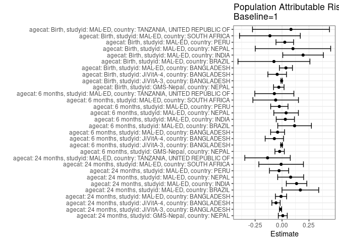

## Results Table

### Parameter: TSM

| agecat | studyid | country | intervention_level | baseline_level | estimate | ci_lower | ci_upper |
| --- | --- | --- | --- | --- | --- | --- | --- |
| Birth | GMS-Nepal | NEPAL | 1 | NA | -1.0255789 | -1.1325437 | -0.9186142 |
| Birth | GMS-Nepal | NEPAL | 0 | NA | -1.2014103 | -1.4639594 | -0.9388612 |
| Birth | JiVitA-3 | BANGLADESH | 1 | NA | -1.5891229 | -1.6130436 | -1.5652022 |
| Birth | JiVitA-3 | BANGLADESH | 0 | NA | -1.6283797 | -1.6923378 | -1.5644215 |
| Birth | JiVitA-4 | BANGLADESH | 1 | NA | -1.5623810 | -1.7668126 | -1.3579493 |
| Birth | JiVitA-4 | BANGLADESH | 0 | NA | -2.0363636 | -2.9086668 | -1.1640605 |
| Birth | MAL-ED | BANGLADESH | 1 | NA | -1.1311932 | -1.2853684 | -0.9770180 |
| Birth | MAL-ED | BANGLADESH | 0 | NA | -0.9315385 | -1.2200144 | -0.6430625 |
| Birth | MAL-ED | BRAZIL | 1 | NA | -0.6245833 | -1.0580810 | -0.1910856 |
| Birth | MAL-ED | BRAZIL | 0 | NA | -0.7542424 | -1.1333475 | -0.3751374 |
| Birth | MAL-ED | INDIA | 1 | NA | -1.4027586 | -1.8015874 | -1.0039298 |
| Birth | MAL-ED | INDIA | 0 | NA | -0.7358333 | -1.1265748 | -0.3450919 |
| Birth | MAL-ED | NEPAL | 1 | NA | -0.9250000 | -1.3150298 | -0.5349702 |
| Birth | MAL-ED | NEPAL | 0 | NA | -0.7050000 | -1.3481239 | -0.0618761 |
| Birth | MAL-ED | PERU | 1 | NA | -0.9009333 | -1.0454225 | -0.7564442 |
| Birth | MAL-ED | PERU | 0 | NA | -0.8228767 | -1.0258474 | -0.6199061 |
| Birth | MAL-ED | SOUTH AFRICA | 1 | NA | -0.4672727 | -0.8095184 | -0.1250271 |
| Birth | MAL-ED | SOUTH AFRICA | 0 | NA | -0.6350746 | -0.8787535 | -0.3913958 |
| Birth | MAL-ED | TANZANIA, UNITED REPUBLIC OF | 1 | NA | -1.1915385 | -1.5906782 | -0.7923987 |
| Birth | MAL-ED | TANZANIA, UNITED REPUBLIC OF | 0 | NA | -1.0802632 | -1.3453886 | -0.8151377 |
| 6 months | GMS-Nepal | NEPAL | 1 | NA | -1.3276521 | -1.4225645 | -1.2327398 |
| 6 months | GMS-Nepal | NEPAL | 0 | NA | -1.4607432 | -1.7003727 | -1.2211138 |
| 6 months | JiVitA-3 | BANGLADESH | 1 | NA | -1.3198344 | -1.3490717 | -1.2905972 |
| 6 months | JiVitA-3 | BANGLADESH | 0 | NA | -1.3677463 | -1.4531825 | -1.2823102 |
| 6 months | JiVitA-4 | BANGLADESH | 1 | NA | -1.1281579 | -1.3158702 | -0.9404456 |
| 6 months | JiVitA-4 | BANGLADESH | 0 | NA | -1.6508333 | -2.2365624 | -1.0651043 |
| 6 months | MAL-ED | BANGLADESH | 1 | NA | -1.1830628 | -1.3088968 | -1.0572289 |
| 6 months | MAL-ED | BANGLADESH | 0 | NA | -1.4117857 | -1.7422315 | -1.0813399 |
| 6 months | MAL-ED | BRAZIL | 1 | NA | -0.0555556 | -0.2808082 | 0.1696971 |
| 6 months | MAL-ED | BRAZIL | 0 | NA | 0.1761348 | -0.0355079 | 0.3877774 |
| 6 months | MAL-ED | INDIA | 1 | NA | -1.2306803 | -1.3811572 | -1.0802033 |
| 6 months | MAL-ED | INDIA | 0 | NA | -1.1292063 | -1.3662905 | -0.8921222 |
| 6 months | MAL-ED | NEPAL | 1 | NA | -0.6011652 | -0.7650788 | -0.4372516 |
| 6 months | MAL-ED | NEPAL | 0 | NA | -0.5259795 | -0.6829512 | -0.3690078 |
| 6 months | MAL-ED | PERU | 1 | NA | -1.2857907 | -1.4149987 | -1.1565828 |
| 6 months | MAL-ED | PERU | 0 | NA | -1.3578369 | -1.5487374 | -1.1669364 |
| 6 months | MAL-ED | SOUTH AFRICA | 1 | NA | -1.0071429 | -1.2464352 | -0.7678506 |
| 6 months | MAL-ED | SOUTH AFRICA | 0 | NA | -1.0867864 | -1.2414215 | -0.9321512 |
| 6 months | MAL-ED | TANZANIA, UNITED REPUBLIC OF | 1 | NA | -1.3316146 | -1.5381589 | -1.1250703 |
| 6 months | MAL-ED | TANZANIA, UNITED REPUBLIC OF | 0 | NA | -1.4339414 | -1.5908360 | -1.2770469 |
| 24 months | GMS-Nepal | NEPAL | 1 | NA | -1.8821066 | -1.9839409 | -1.7802724 |
| 24 months | GMS-Nepal | NEPAL | 0 | NA | -1.8399462 | -2.0757145 | -1.6041780 |
| 24 months | JiVitA-3 | BANGLADESH | 1 | NA | -2.0048669 | -2.0428260 | -1.9669079 |
| 24 months | JiVitA-3 | BANGLADESH | 0 | NA | -2.1658134 | -2.2765299 | -2.0550969 |
| 24 months | JiVitA-4 | BANGLADESH | 1 | NA | -1.7167647 | -1.8644623 | -1.5690671 |
| 24 months | JiVitA-4 | BANGLADESH | 0 | NA | -2.2793333 | -2.5658569 | -1.9928098 |
| 24 months | MAL-ED | BANGLADESH | 1 | NA | -1.9922917 | -2.1395476 | -1.8450358 |
| 24 months | MAL-ED | BANGLADESH | 0 | NA | -2.0441892 | -2.2910750 | -1.7973034 |
| 24 months | MAL-ED | BRAZIL | 1 | NA | -0.1863080 | -0.4234712 | 0.0508552 |
| 24 months | MAL-ED | BRAZIL | 0 | NA | 0.1676941 | -0.0890477 | 0.4244359 |
| 24 months | MAL-ED | INDIA | 1 | NA | -2.0341367 | -2.1909113 | -1.8773620 |
| 24 months | MAL-ED | INDIA | 0 | NA | -1.6021429 | -1.8483255 | -1.3559602 |
| 24 months | MAL-ED | NEPAL | 1 | NA | -1.3910000 | -1.5566768 | -1.2253232 |
| 24 months | MAL-ED | NEPAL | 0 | NA | -1.2308636 | -1.4044362 | -1.0572911 |
| 24 months | MAL-ED | PERU | 1 | NA | -1.7137532 | -1.8596781 | -1.5678282 |
| 24 months | MAL-ED | PERU | 0 | NA | -1.7951493 | -2.0138894 | -1.5764092 |
| 24 months | MAL-ED | SOUTH AFRICA | 1 | NA | -1.6340556 | -1.8576999 | -1.4104113 |
| 24 months | MAL-ED | SOUTH AFRICA | 0 | NA | -1.6454514 | -1.8155088 | -1.4753940 |
| 24 months | MAL-ED | TANZANIA, UNITED REPUBLIC OF | 1 | NA | -2.5424074 | -2.7813230 | -2.3034918 |
| 24 months | MAL-ED | TANZANIA, UNITED REPUBLIC OF | 0 | NA | -2.7326538 | -2.9105963 | -2.5547114 |

### Parameter: E(Y)

| agecat | studyid | country | intervention_level | baseline_level | estimate | ci_lower | ci_upper |
| --- | --- | --- | --- | --- | --- | --- | --- |
| Birth | GMS-Nepal | NEPAL | NA | NA | -1.0555240 | -1.1550843 | -0.9559638 |
| Birth | JiVitA-3 | BANGLADESH | NA | NA | -1.5928457 | -1.6158667 | -1.5698248 |
| Birth | JiVitA-4 | BANGLADESH | NA | NA | -1.6073276 | -1.8105798 | -1.4040753 |
| Birth | MAL-ED | BANGLADESH | NA | NA | -1.0949767 | -1.2319917 | -0.9579618 |
| Birth | MAL-ED | BRAZIL | NA | NA | -0.6996491 | -0.9856018 | -0.4136965 |
| Birth | MAL-ED | INDIA | NA | NA | -1.2075610 | -1.5261540 | -0.8889679 |
| Birth | MAL-ED | NEPAL | NA | NA | -0.8234615 | -1.1896049 | -0.4573182 |
| Birth | MAL-ED | PERU | NA | NA | -0.8753812 | -0.9932108 | -0.7575515 |
| Birth | MAL-ED | SOUTH AFRICA | NA | NA | -0.5797000 | -0.7788298 | -0.3805702 |
| Birth | MAL-ED | TANZANIA, UNITED REPUBLIC OF | NA | NA | -1.1086275 | -1.3310338 | -0.8862211 |
| 6 months | GMS-Nepal | NEPAL | NA | NA | -1.3499849 | -1.4387386 | -1.2612312 |
| 6 months | JiVitA-3 | BANGLADESH | NA | NA | -1.3240051 | -1.3526414 | -1.2953689 |
| 6 months | JiVitA-4 | BANGLADESH | NA | NA | -1.1994318 | -1.3808291 | -1.0180345 |
| 6 months | MAL-ED | BANGLADESH | NA | NA | -1.2242918 | -1.3439424 | -1.1046413 |
| 6 months | MAL-ED | BRAZIL | NA | NA | 0.0609091 | -0.0944768 | 0.2162950 |
| 6 months | MAL-ED | INDIA | NA | NA | -1.2002381 | -1.3274929 | -1.0729833 |
| 6 months | MAL-ED | NEPAL | NA | NA | -0.5634068 | -0.6769687 | -0.4498449 |
| 6 months | MAL-ED | PERU | NA | NA | -1.3108735 | -1.4182407 | -1.2035062 |
| 6 months | MAL-ED | SOUTH AFRICA | NA | NA | -1.0662227 | -1.1965862 | -0.9358591 |
| 6 months | MAL-ED | TANZANIA, UNITED REPUBLIC OF | NA | NA | -1.4030503 | -1.5292443 | -1.2768563 |
| 24 months | GMS-Nepal | NEPAL | NA | NA | -1.8752995 | -1.9688053 | -1.7817937 |
| 24 months | JiVitA-3 | BANGLADESH | NA | NA | -2.0187325 | -2.0554682 | -1.9819968 |
| 24 months | JiVitA-4 | BANGLADESH | NA | NA | -1.7726490 | -1.9111913 | -1.6341067 |
| 24 months | MAL-ED | BANGLADESH | NA | NA | -2.0016585 | -2.1303297 | -1.8729874 |
| 24 months | MAL-ED | BRAZIL | NA | NA | -0.0162939 | -0.1929098 | 0.1603221 |
| 24 months | MAL-ED | INDIA | NA | NA | -1.8994059 | -2.0346781 | -1.7641337 |
| 24 months | MAL-ED | NEPAL | NA | NA | -1.3109318 | -1.4313748 | -1.1904888 |
| 24 months | MAL-ED | PERU | NA | NA | -1.7412963 | -1.8630698 | -1.6195228 |
| 24 months | MAL-ED | SOUTH AFRICA | NA | NA | -1.6424525 | -1.7808926 | -1.5040124 |
| 24 months | MAL-ED | TANZANIA, UNITED REPUBLIC OF | NA | NA | -2.6768207 | -2.8213178 | -2.5323235 |

### Parameter: ATE

| agecat | studyid | country | intervention_level | baseline_level | estimate | ci_lower | ci_upper |
| --- | --- | --- | --- | --- | --- | --- | --- |
| Birth | GMS-Nepal | NEPAL | 1 | 1 | 0.0000000 | 0.0000000 | 0.0000000 |
| Birth | GMS-Nepal | NEPAL | 0 | 1 | -0.1758313 | -0.4593335 | 0.1076709 |
| Birth | JiVitA-3 | BANGLADESH | 1 | 1 | 0.0000000 | 0.0000000 | 0.0000000 |
| Birth | JiVitA-3 | BANGLADESH | 0 | 1 | -0.0392568 | -0.1054679 | 0.0269544 |
| Birth | JiVitA-4 | BANGLADESH | 1 | 1 | 0.0000000 | 0.0000000 | 0.0000000 |
| Birth | JiVitA-4 | BANGLADESH | 0 | 1 | -0.4739827 | -1.3698066 | 0.4218412 |
| Birth | MAL-ED | BANGLADESH | 1 | 1 | 0.0000000 | 0.0000000 | 0.0000000 |
| Birth | MAL-ED | BANGLADESH | 0 | 1 | 0.1996547 | -0.1274360 | 0.5267455 |
| Birth | MAL-ED | BRAZIL | 1 | 1 | 0.0000000 | 0.0000000 | 0.0000000 |
| Birth | MAL-ED | BRAZIL | 0 | 1 | -0.1296591 | -0.7055418 | 0.4462236 |
| Birth | MAL-ED | INDIA | 1 | 1 | 0.0000000 | 0.0000000 | 0.0000000 |
| Birth | MAL-ED | INDIA | 0 | 1 | 0.6669253 | 0.1085855 | 1.2252651 |
| Birth | MAL-ED | NEPAL | 1 | 1 | 0.0000000 | 0.0000000 | 0.0000000 |
| Birth | MAL-ED | NEPAL | 0 | 1 | 0.2200000 | -0.5321513 | 0.9721513 |
| Birth | MAL-ED | PERU | 1 | 1 | 0.0000000 | 0.0000000 | 0.0000000 |
| Birth | MAL-ED | PERU | 0 | 1 | 0.0780566 | -0.1710903 | 0.3272036 |
| Birth | MAL-ED | SOUTH AFRICA | 1 | 1 | 0.0000000 | 0.0000000 | 0.0000000 |
| Birth | MAL-ED | SOUTH AFRICA | 0 | 1 | -0.1678019 | -0.5879346 | 0.2523308 |
| Birth | MAL-ED | TANZANIA, UNITED REPUBLIC OF | 1 | 1 | 0.0000000 | 0.0000000 | 0.0000000 |
| Birth | MAL-ED | TANZANIA, UNITED REPUBLIC OF | 0 | 1 | 0.1112753 | -0.3678948 | 0.5904454 |
| 6 months | GMS-Nepal | NEPAL | 1 | 1 | 0.0000000 | 0.0000000 | 0.0000000 |
| 6 months | GMS-Nepal | NEPAL | 0 | 1 | -0.1330911 | -0.3908325 | 0.1246503 |
| 6 months | JiVitA-3 | BANGLADESH | 1 | 1 | 0.0000000 | 0.0000000 | 0.0000000 |
| 6 months | JiVitA-3 | BANGLADESH | 0 | 1 | -0.0479119 | -0.1345127 | 0.0386890 |
| 6 months | JiVitA-4 | BANGLADESH | 1 | 1 | 0.0000000 | 0.0000000 | 0.0000000 |
| 6 months | JiVitA-4 | BANGLADESH | 0 | 1 | -0.5226754 | -1.1367392 | 0.0913883 |
| 6 months | MAL-ED | BANGLADESH | 1 | 1 | 0.0000000 | 0.0000000 | 0.0000000 |
| 6 months | MAL-ED | BANGLADESH | 0 | 1 | -0.2287229 | -0.5823168 | 0.1248710 |
| 6 months | MAL-ED | BRAZIL | 1 | 1 | 0.0000000 | 0.0000000 | 0.0000000 |
| 6 months | MAL-ED | BRAZIL | 0 | 1 | 0.2316903 | -0.0773912 | 0.5407718 |
| 6 months | MAL-ED | INDIA | 1 | 1 | 0.0000000 | 0.0000000 | 0.0000000 |
| 6 months | MAL-ED | INDIA | 0 | 1 | 0.1014739 | -0.1793325 | 0.3822803 |
| 6 months | MAL-ED | NEPAL | 1 | 1 | 0.0000000 | 0.0000000 | 0.0000000 |
| 6 months | MAL-ED | NEPAL | 0 | 1 | 0.0751857 | -0.1517676 | 0.3021389 |
| 6 months | MAL-ED | PERU | 1 | 1 | 0.0000000 | 0.0000000 | 0.0000000 |
| 6 months | MAL-ED | PERU | 0 | 1 | -0.0720462 | -0.3025623 | 0.1584700 |
| 6 months | MAL-ED | SOUTH AFRICA | 1 | 1 | 0.0000000 | 0.0000000 | 0.0000000 |
| 6 months | MAL-ED | SOUTH AFRICA | 0 | 1 | -0.0796435 | -0.3645520 | 0.2052650 |
| 6 months | MAL-ED | TANZANIA, UNITED REPUBLIC OF | 1 | 1 | 0.0000000 | 0.0000000 | 0.0000000 |
| 6 months | MAL-ED | TANZANIA, UNITED REPUBLIC OF | 0 | 1 | -0.1023269 | -0.3617039 | 0.1570502 |
| 24 months | GMS-Nepal | NEPAL | 1 | 1 | 0.0000000 | 0.0000000 | 0.0000000 |
| 24 months | GMS-Nepal | NEPAL | 0 | 1 | 0.0421604 | -0.2146603 | 0.2989811 |
| 24 months | JiVitA-3 | BANGLADESH | 1 | 1 | 0.0000000 | 0.0000000 | 0.0000000 |
| 24 months | JiVitA-3 | BANGLADESH | 0 | 1 | -0.1609465 | -0.2758329 | -0.0460600 |
| 24 months | JiVitA-4 | BANGLADESH | 1 | 1 | 0.0000000 | 0.0000000 | 0.0000000 |
| 24 months | JiVitA-4 | BANGLADESH | 0 | 1 | -0.5625686 | -0.8839259 | -0.2412114 |
| 24 months | MAL-ED | BANGLADESH | 1 | 1 | 0.0000000 | 0.0000000 | 0.0000000 |
| 24 months | MAL-ED | BANGLADESH | 0 | 1 | -0.0518975 | -0.3393639 | 0.2355688 |
| 24 months | MAL-ED | BRAZIL | 1 | 1 | 0.0000000 | 0.0000000 | 0.0000000 |
| 24 months | MAL-ED | BRAZIL | 0 | 1 | 0.3540021 | 0.0044842 | 0.7035199 |
| 24 months | MAL-ED | INDIA | 1 | 1 | 0.0000000 | 0.0000000 | 0.0000000 |
| 24 months | MAL-ED | INDIA | 0 | 1 | 0.4319938 | 0.1401305 | 0.7238571 |
| 24 months | MAL-ED | NEPAL | 1 | 1 | 0.0000000 | 0.0000000 | 0.0000000 |
| 24 months | MAL-ED | NEPAL | 0 | 1 | 0.1601364 | -0.0798141 | 0.4000868 |
| 24 months | MAL-ED | PERU | 1 | 1 | 0.0000000 | 0.0000000 | 0.0000000 |
| 24 months | MAL-ED | PERU | 0 | 1 | -0.0813961 | -0.3443434 | 0.1815513 |
| 24 months | MAL-ED | SOUTH AFRICA | 1 | 1 | 0.0000000 | 0.0000000 | 0.0000000 |
| 24 months | MAL-ED | SOUTH AFRICA | 0 | 1 | -0.0113958 | -0.2923519 | 0.2695602 |
| 24 months | MAL-ED | TANZANIA, UNITED REPUBLIC OF | 1 | 1 | 0.0000000 | 0.0000000 | 0.0000000 |
| 24 months | MAL-ED | TANZANIA, UNITED REPUBLIC OF | 0 | 1 | -0.1902464 | -0.4881460 | 0.1076532 |

### Parameter: PAR

| agecat | studyid | country | intervention_level | baseline_level | estimate | ci_lower | ci_upper |
| --- | --- | --- | --- | --- | --- | --- | --- |
| Birth | GMS-Nepal | NEPAL | 1 | NA | -0.0299451 | -0.0786059 | 0.0187158 |
| Birth | JiVitA-3 | BANGLADESH | 1 | NA | -0.0037228 | -0.0099995 | 0.0025538 |
| Birth | JiVitA-4 | BANGLADESH | 1 | NA | -0.0449466 | -0.1313789 | 0.0414857 |
| Birth | MAL-ED | BANGLADESH | 1 | NA | 0.0362164 | -0.0240050 | 0.0964379 |
| Birth | MAL-ED | BRAZIL | 1 | NA | -0.0750658 | -0.4088929 | 0.2587613 |
| Birth | MAL-ED | INDIA | 1 | NA | 0.1951976 | 0.0066558 | 0.3837394 |
| Birth | MAL-ED | NEPAL | 1 | NA | 0.1015385 | -0.2482603 | 0.4513372 |
| Birth | MAL-ED | PERU | 1 | NA | 0.0255522 | -0.0561493 | 0.1072537 |
| Birth | MAL-ED | SOUTH AFRICA | 1 | NA | -0.1124273 | -0.3943449 | 0.1694904 |
| Birth | MAL-ED | TANZANIA, UNITED REPUBLIC OF | 1 | NA | 0.0829110 | -0.2742430 | 0.4400650 |
| 6 months | GMS-Nepal | NEPAL | 1 | NA | -0.0223327 | -0.0658308 | 0.0211653 |
| 6 months | JiVitA-3 | BANGLADESH | 1 | NA | -0.0041707 | -0.0117276 | 0.0033861 |
| 6 months | JiVitA-4 | BANGLADESH | 1 | NA | -0.0712739 | -0.1565875 | 0.0140397 |
| 6 months | MAL-ED | BANGLADESH | 1 | NA | -0.0412290 | -0.1059633 | 0.0235052 |
| 6 months | MAL-ED | BRAZIL | 1 | NA | 0.1164646 | -0.0397919 | 0.2727212 |
| 6 months | MAL-ED | INDIA | 1 | NA | 0.0304422 | -0.0540353 | 0.1149197 |
| 6 months | MAL-ED | NEPAL | 1 | NA | 0.0377584 | -0.0763234 | 0.1518403 |
| 6 months | MAL-ED | PERU | 1 | NA | -0.0250827 | -0.1054412 | 0.0552758 |
| 6 months | MAL-ED | SOUTH AFRICA | 1 | NA | -0.0590798 | -0.2704713 | 0.1523116 |
| 6 months | MAL-ED | TANZANIA, UNITED REPUBLIC OF | 1 | NA | -0.0714357 | -0.2526212 | 0.1097497 |
| 24 months | GMS-Nepal | NEPAL | 1 | NA | 0.0068071 | -0.0346878 | 0.0483021 |
| 24 months | JiVitA-3 | BANGLADESH | 1 | NA | -0.0138655 | -0.0239176 | -0.0038135 |
| 24 months | JiVitA-4 | BANGLADESH | 1 | NA | -0.0558843 | -0.0944100 | -0.0173586 |
| 24 months | MAL-ED | BANGLADESH | 1 | NA | -0.0093669 | -0.0613233 | 0.0425895 |
| 24 months | MAL-ED | BRAZIL | 1 | NA | 0.1700142 | -0.0002002 | 0.3402286 |
| 24 months | MAL-ED | INDIA | 1 | NA | 0.1347308 | 0.0395925 | 0.2298690 |
| 24 months | MAL-ED | NEPAL | 1 | NA | 0.0800682 | -0.0403748 | 0.2005112 |
| 24 months | MAL-ED | PERU | 1 | NA | -0.0275431 | -0.1166826 | 0.0615964 |
| 24 months | MAL-ED | SOUTH AFRICA | 1 | NA | -0.0083969 | -0.2154182 | 0.1986243 |
| 24 months | MAL-ED | TANZANIA, UNITED REPUBLIC OF | 1 | NA | -0.1344132 | -0.3452597 | 0.0764332 |